# COUNTERCOVID analysis

Lina Kramer

1.03.2025

### 1. Data overview

- Exposure: imatinib vs. placebo.
- Survival outcome: 28-day survival.
- Mediator: IL6 on days 0, 2, 3, 5.

```r
countercovid_long <- readRDS("./countercovid_long.rds")
countercovid_surv <- readRDS("./countercovid_surv.rds")
```

### 2. Descriptives

#### 2.1. Table 1

```r
countercovid_wide <- countercovid_long%>% select(!c(endt, endt28)) %>%
  unite("biomarker_day", biomarker, day, sep = "_") %>%
  pivot_wider(names_from = biomarker_day, values_from = conc_log10) %>%
  mutate(IL6_0 = gsub("NULL", NA, IL6_0) %>% as.numeric(),
         IL6_2 = gsub("NULL", NA, IL6_2) %>% as.numeric(),
         IL6_3 = gsub("NULL", NA, IL6_3) %>% as.numeric(),
         IL6_5 = gsub("NULL", NA, IL6_5) %>% as.numeric())

tableone::CreateTableOne(countercovid_wide, strata = "randomized_group", vars = c("death_d28", "death_d90", "IL6_0", "IL6_2", "IL6_3", "IL6_5", "sex","age", "bmi"), factorVars = c("death_d28", "death_d90", "randomized_group", "sex"), test = F) %>% print()
```

```
##                    Stratified by randomized_group
##                     Imatinib      Placebo
##   n                   168           163
##   death_d28 = 1 (%)    13 ( 7.7)     24 (14.7)
##   death_d90 = 1 (%)    15 ( 8.9)     28 (17.3)
##   IL6_0 (mean (SD))  1.03 (0.43)   1.12 (0.41)
##   IL6_2 (mean (SD))  0.85 (0.49)   1.10 (0.46)
##   IL6_3 (mean (SD))  1.04 (0.51)   1.14 (0.48)
##   IL6_5 (mean (SD))  0.75 (0.59)   1.07 (0.54)
##   sex = male (%)      126 (75.0)    108 (66.3)
##   age (mean (SD))   64.45 (12.46) 63.76 (12.86)
##   bmi (mean (SD))   28.58 (5.46)  30.03 (5.51)
```

#### 2.2. Missingness

Of 386 patients, 55 have no IL-6 biomarker measures. They are not included in any of the analyses.

For the 331 subjects who do have IL6 measures, this is the pattern of missingness:

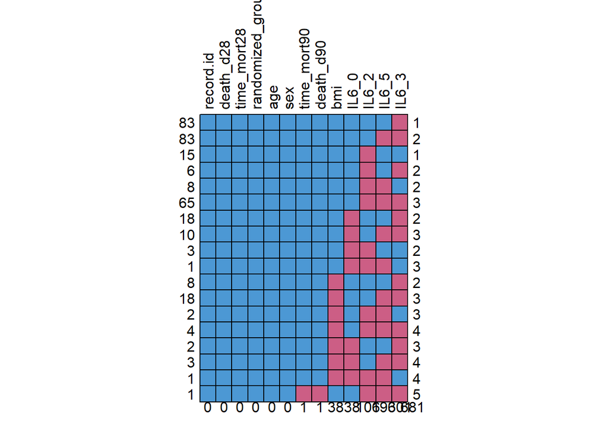

```r
missing_countercovid <- mice::md.pattern(countercovid_wide, rotate.names = TRUE)
```

#### 2.3. 28-day survival

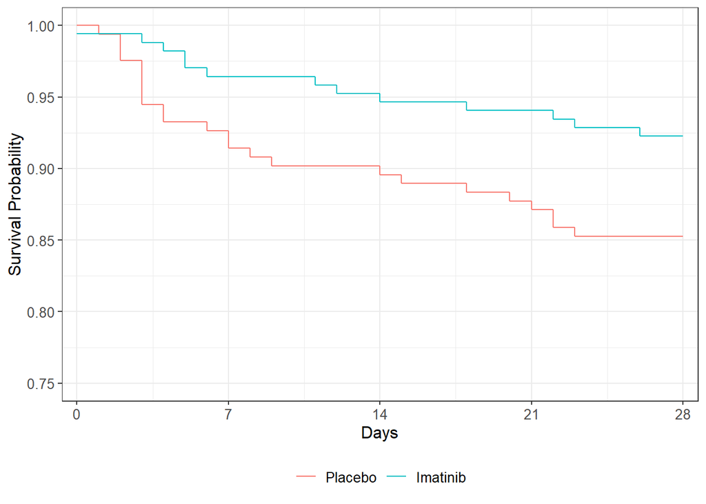

```r
# set the reference group
countercovid_long$randomized_group <- countercovid_long$randomized_group %>% as.factor()
countercovid_long$randomized_group <- countercovid_long$randomized_group%>% relevel(ref = "Placebo")
countercovid_surv$randomized_group <- countercovid_surv$randomized_group %>% as.factor()
countercovid_surv$randomized_group <- countercovid_surv$randomized_group %>%  relevel(ref = "Placebo")

class(countercovid_surv$death_d28) <- "integer"

survfit2(Surv(time_mort28, death_d28) ~ randomized_group, data = countercovid_surv) %>%
  ggsurvfit() + scale_ggsurvfit(x_scales= list(breaks = c(0, 7, 14, 21, 28))) +
  ylim(c(.75, 1))+
  xlab("Days")
```

#### 2.4. 90-day survival

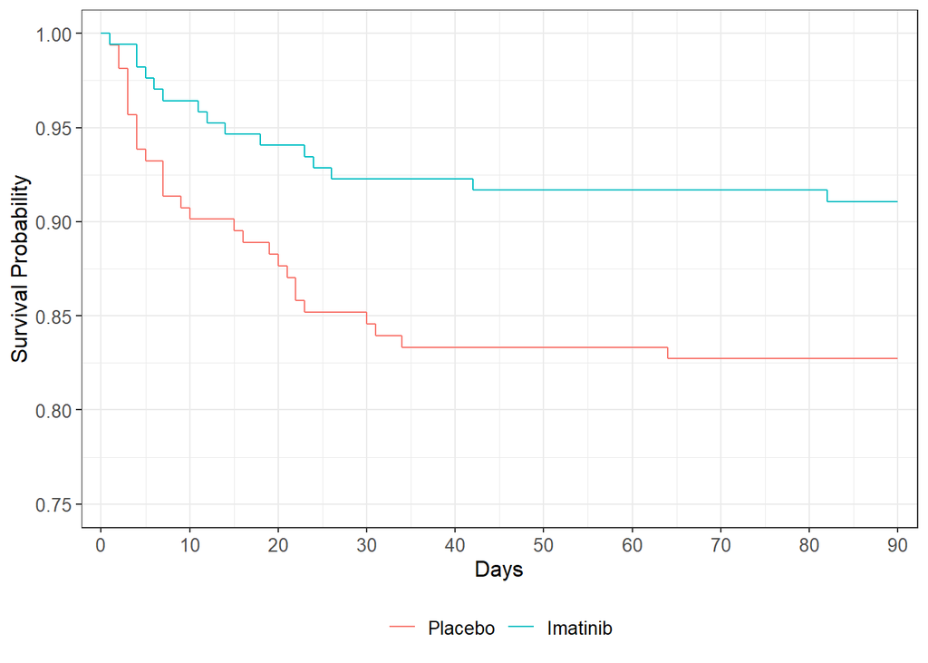

```r
class(countercovid_surv$death_d90) <- "integer"

survfit2(Surv(time_mort90, death_d90) ~ randomized_group, data = countercovid_surv) %>%
  ggsurvfit() + scale_ggsurvfit(x_scales= list(breaks = seq(0,90,10))) +
  ylim(c(.75, 1))+
  xlab("Days")
```

#### 2.5. IL6 over time

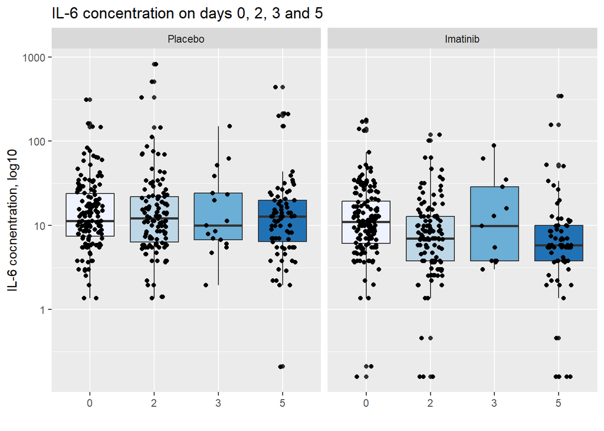

```r
countercovid_long %>% drop_na(conc_log10) %>%
  ggplot(aes(as.factor(day), 10^conc_log10, fill = as.factor(day)))+
  geom_boxplot() +
  geom_jitter(width = .2)+
  geom_smooth()+
  guides(fill = "none") +
  labs(x = "", y = "IL-6 cocnentration, log10")+
  scale_y_continuous(trans = "log10")+
  facet_grid(cols = vars(randomized_group))+
  ggtitle("IL-6 concentration on days 0, 2, 3 and 5")+
  scale_fill_brewer()
```

### 3. Models

#### 3.1. Linear-mixed model for IL-6 over time

Note: there is one patient with missing 90 day survival data. A separate lm is fit where we exclude this patient. This is necessary to have the same subjects in the longitudinal and survival submodels of the joint model.

```r
## Fit linear mixed model for biomarker concentration

lmefit.countercovid <- lme(conc_log10~ day:randomized_group +day,
                   random = ~ day | record.id,
                   data = countercovid_long,
                  control = lmeControl(opt = "optim"),
                  na.action = na.omit)

summary(lmefit.countercovid)
```

```
## Linear mixed-effects model fit by REML
##   Data: countercovid_long
##        AIC      BIC    logLik
##   821.9867 853.8542 -403.9933
##
## Random effects:
##  Formula: ~day | record.id
##  Structure: General positive-definite, Log-Cholesky parametrization
##             StdDev     Corr
## (Intercept) 0.33420336 (Intr)
## day         0.06973354 -0.018
## Residual    0.29178962
##
## Fixed effects:  conc_log10 ~ day:randomized_group + day
##                                   Value  Std.Error  DF  t-value p-value
## (Intercept)                   1.0826867 0.02433411 371 44.49256  0.0000
## day                          -0.0147687 0.01137807 371 -1.29800  0.1951
## day:randomized_groupImatinib -0.0613266 0.01552601 371 -3.94992  0.0001
##  Correlation:
##                              (Intr) day
## day                          -0.282
## day:randomized_groupImatinib  0.007 -0.677
##
## Standardized Within-Group Residuals:
##         Min          Q1         Med          Q3         Max
## -4.75444869 -0.39035017 -0.01291234  0.32388527  3.83083236
##
## Number of Observations: 704
## Number of Groups: 331
```

```r
lmefit.countercovid_90 <- countercovid_long %>%
  filter(!is.na(death_d90)) %>%
  lme(conc_log10~ day:randomized_group,
                   random = ~ day | record.id,
                   data = .,
                  control = lmeControl(opt = "optim"),
                  na.action = na.omit)

summary(lmefit.countercovid_90)
```

```
## Linear mixed-effects model fit by REML
##   Data: .
##       AIC      BIC    logLik
##   821.249 853.1065 -403.6245
##
## Random effects:
##  Formula: ~day | record.id
##  Structure: General positive-definite, Log-Cholesky parametrization
##             StdDev     Corr
## (Intercept) 0.33463777 (Intr)
## day         0.06974882 -0.019
## Residual    0.29179148
##
## Fixed effects:  conc_log10 ~ day:randomized_group
##                                   Value  Std.Error  DF  t-value p-value
## (Intercept)                   1.0836557 0.02438946 371 44.43130  0.0000
## day:randomized_groupPlacebo  -0.0148995 0.01137977 371 -1.30930  0.1912
## day:randomized_groupImatinib -0.0762125 0.01146541 371 -6.64717  0.0000
##  Correlation:
##                              (Intr) dy:r_P
## day:randomized_groupPlacebo  -0.282
## day:randomized_groupImatinib -0.270  0.076
##
## Standardized Within-Group Residuals:
##         Min          Q1         Med          Q3         Max
## -4.75467879 -0.39009716 -0.01326511  0.32357112  3.82916219
##
## Number of Observations: 703
## Number of Groups: 330
```

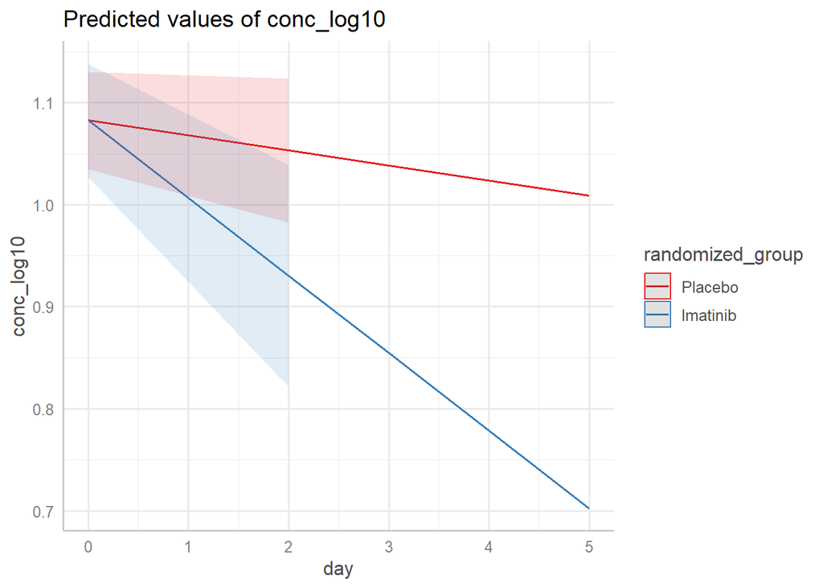

```r
library(sjPlot)
library(sjmisc)
theme_set(theme_sjplot())

plot_model(lmefit.countercovid, type = "int", terms = c("randomized_group", "day"))
```

```r
# save the interaction estimate
a_res <- get_int(lmefit.countercovid, "randomized_groupImatinib")

saveRDS(a_res, "COUNTERCOVID_beta_est.rds")
```

#### 3.2. Cox proportional hazards model

##### 3.2.1. 28-day survival

```r
## fit cox ph model
coxfit.countercovid_28 <- coxph(Surv(time_mort28, death_d28)~ randomized_group, data = countercovid_surv, x=TRUE)
summary(coxfit.countercovid_28)
```

```
## Call:
## coxph(formula = Surv(time_mort28, death_d28) ~ randomized_group,
##     data = countercovid_surv, x = TRUE)
##
##   n= 331, number of events= 37
##
##                             coef exp(coef) se(coef)      z Pr(>|z|)
## randomized_groupImatinib -0.6907    0.5012   0.3444 -2.006   0.0449 *
## ---
## Signif. codes:  0 '***' 0.001 '**' 0.01 '*' 0.05 '.' 0.1 ' ' 1
##
##                          exp(coef) exp(-coef) lower .95 upper .95
## randomized_groupImatinib    0.5012      1.995    0.2552    0.9844
##
## Concordance= 0.586  (se = 0.039 )
## Likelihood ratio test= 4.23  on 1 df,   p=0.04
## Wald test            = 4.02  on 1 df,   p=0.04
## Score (logrank) test = 4.18  on 1 df,   p=0.04
```

```r
confint(coxfit.countercovid_28) %>% exp() %>% round(3)
```

```
##                          2.5 % 97.5 %
## randomized_groupImatinib 0.255  0.984
```

##### 3.2.2. 90-day survival

```r
## fit cox ph model
coxfit.countercovid_90 <- coxph(Surv(time_mort90, death_d90)~ randomized_group, data = countercovid_surv,
                                x=TRUE)

summary(coxfit.countercovid_90)
```

```
## Call:
## coxph(formula = Surv(time_mort90, death_d90) ~ randomized_group,
##     data = countercovid_surv, x = TRUE)
##
##   n= 330, number of events= 43
##    (1 observation deleted due to missingness)
##
##                             coef exp(coef) se(coef)      z Pr(>|z|)
## randomized_groupImatinib -0.7156    0.4889   0.3200 -2.236   0.0253 *
## ---
## Signif. codes:  0 '***' 0.001 '**' 0.01 '*' 0.05 '.' 0.1 ' ' 1
##
##                          exp(coef) exp(-coef) lower .95 upper .95
## randomized_groupImatinib    0.4889      2.045    0.2611    0.9154
##
## Concordance= 0.589  (se = 0.037 )
## Likelihood ratio test= 5.27  on 1 df,   p=0.02
## Wald test            = 5  on 1 df,   p=0.03
## Score (logrank) test = 5.22  on 1 df,   p=0.02
```

#### 3.3. Joint model

Using 28-day and 90-day survival as endpoints

##### 3.3.1. 28-day endpoint

```r
set.seed(15)

## fit joint model
jointfit.countercovid_28<- JMbayes2::jm(coxfit.countercovid_28, lmefit.countercovid, time_var = "day", n_iter = 60000L, n_burnin = 5000L, n_chains = 2L, n_thin = 5L, cores= 2)

summary(jointfit.countercovid_28)

saveRDS(jointfit.countercovid_28, "./jointfit_countercovid_28.rds")
```

```
##
## Call:
## JMbayes2::jm(Surv_object = coxfit.countercovid_28, Mixed_objects = lmefit.countercovid,
##     time_var = "day", n_iter = 60000L, n_burnin = 5000L, n_chains = 2L,
##     n_thin = 5L, cores = 2)
##
## Data Descriptives:
## Number of Groups: 331        Number of events: 37 (11.2%)
## Number of Observations:
##   conc_log10: 704
##
##                   DIC      WAIC      LPML
## marginal    1197.6815 1272.6692 -697.4384
## conditional  408.7553  300.0128 -454.1746
##
## Random-effects covariance matrix:
##
##        StdDev   Corr
## (Intr) 0.3198 (Intr)
## day    0.0502 0.3110
##
## Survival Outcome:
##                            Mean  StDev   2.5%  97.5%      P   Rhat
## randomized_groupImatinib 0.0125 0.5187 -1.013 1.0149 0.9814 1.0002
## value(conc_log10)        1.5326 0.5059  0.666 2.6977 0.0004 1.0026
##
## Longitudinal Outcome: conc_log10 (family = gaussian, link = identity)
##                Mean  StDev    2.5%   97.5%      P   Rhat
## (Intercept)  1.0838 0.0241  1.0362  1.1308 0.0000 1.0007
## day         -0.0211 0.0105 -0.0417 -0.0004 0.0452 1.0023
## d:_I        -0.0485 0.0145 -0.0768 -0.0203 0.0007 1.0003
## sigma        0.3088 0.0136  0.2832  0.3362 0.0000 0.9999
##
## MCMC summary:
## chains: 2
## iterations per chain: 60000
## burn-in per chain: 5000
## thinning: 5
## time: 3.5 min
```

##### 3.3.2. 90-day endpoint

```r
set.seed(15)

## fit joint model
jointfit.countercovid_90<- JMbayes2::jm(coxfit.countercovid_90, lmefit.countercovid_90, time_var = "day", n_iter = 60000L, n_burnin = 5000L, n_chains = 2L, n_thin = 5L, cores= 2)

summary(jointfit.countercovid_90)

saveRDS(jointfit.countercovid_90, "jointfit_countercovid_90.rds")
```

```
##
## Call:
## JMbayes2::jm(Surv_object = coxfit.countercovid_90, Mixed_objects = lmefit.countercovid_90,
##     time_var = "day", n_iter = 60000L, n_burnin = 5000L, n_chains = 2L,
##     n_thin = 5L, cores = 2)
##
## Data Descriptives:
## Number of Groups: 330        Number of events: 43 (13%)
## Number of Observations:
##   conc_log10: 703
##
##                   DIC        WAIC         LPML
## marginal    1345.2180    1382.686    -786.7081
## conditional  687.2757 1408448.116 -283793.7446
##
## Random-effects covariance matrix:
##
##        StdDev   Corr
## (Intr) 0.3219 (Intr)
## day    0.0589 0.2081
##
## Survival Outcome:
##                             Mean  StDev    2.5%  97.5%      P   Rhat
## randomized_groupImatinib -0.1862 0.4778 -1.1184 0.7473 0.6943 1.0004
## value(conc_log10)         0.9843 0.2569  0.4949 1.4790 0.0000 1.0611
##
## Longitudinal Outcome: conc_log10 (family = gaussian, link = identity)
##                Mean  StDev    2.5%   97.5%      P   Rhat
## (Intercept)  1.0853 0.0243  1.0382  1.1330 0.0000 1.0002
## day         -0.0245 0.0108 -0.0455 -0.0031 0.0233 1.0005
## d:_I        -0.0445 0.0145 -0.0736 -0.0166 0.0011 1.0008
## sigma        0.3030 0.0135  0.2773  0.3301 0.0000 1.0033
##
## MCMC summary:
## chains: 2
## iterations per chain: 60000
## burn-in per chain: 5000
## thinning: 5
## time: 4.1 min
```

### 4. Results

#### 4.1. Indirect, direct, and total effects

Of imatinib through IL6 on 28-day mortality

```r
res28 <- get_effects(jointfit.countercovid_28, coxfit.countercovid_28, "randomized_groupImatinib") %>% cbind(endpoint =c("28-day endpoint"))

res28
```

```
##           effect         est   CI_lower    CI_upper        endpoint
## 1         direct  0.01250247 -1.0130430  1.01488399 28-day endpoint
## 2       indirect -0.07431096 -0.1345114 -0.02480730 28-day endpoint
## 3 total (Cox-PH) -0.69070841 -1.3657040 -0.01571283 28-day endpoint
## 4     total (JM) -0.06180850 -1.0664945  0.91792515 28-day endpoint
```

```r
res90 <- get_effects(jointfit.countercovid_90, coxfit.countercovid_90, "randomized_groupImatinib")%>% cbind(endpoint =c("90-day endpoint"))

res90
```

```
##           effect         est    CI_lower    CI_upper        endpoint
## 1         direct -0.18619161 -1.11843854  0.74734402 90-day endpoint
## 2       indirect -0.04380764 -0.07914674 -0.01483965 90-day endpoint
## 3 total (Cox-PH) -0.71560268 -1.34278903 -0.08841633 90-day endpoint
## 4     total (JM) -0.22999924 -1.14980734  0.68759550 90-day endpoint
```

```r
res <- rbind(res28, res90)

saveRDS(res, "countercovid_res.rds")
```

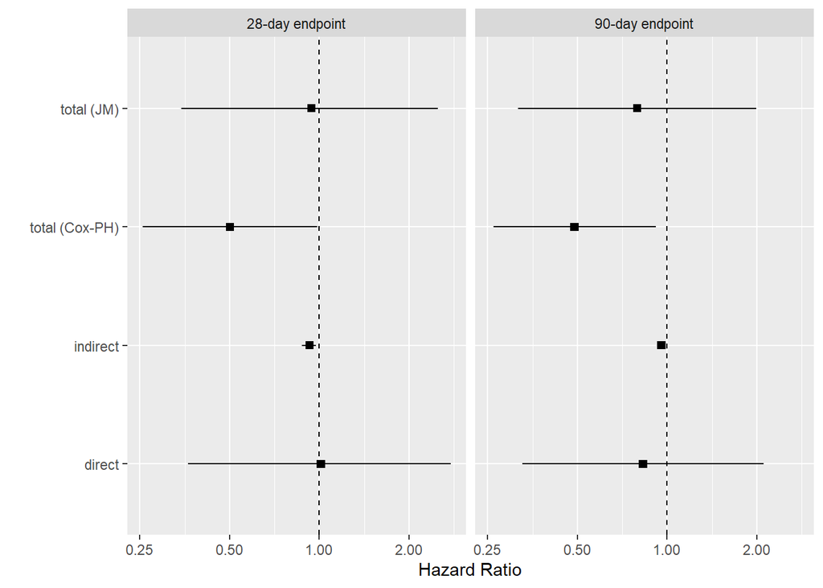

```r
res %>%
  ggplot(aes(y = effect))+
  theme_grey()+
  geom_point(aes(x=exp(est)), shape=15, size=2) +
  geom_linerange(aes(xmin=exp(CI_lower), xmax=exp(CI_upper))) +
   geom_vline(xintercept = 1, linetype="dashed") +
  labs(x="Hazard Ratio", y= "")+
  scale_x_continuous(trans = "log2")+
  facet_grid(~endpoint)
```

#### 4.2. Association parameter

Hazard ratio estimate and 95% CI for the association parameter $\alpha$ for a one unit increase (at any time point) of IL-6 and the hazard of death over 28 days.

```r
print(paste0("HR alpha = ", round(exp(jointfit.countercovid_28$statistics$Mean$alphas),3), ", ", "95% CI = [", round(exp(quantile(unlist(jointfit.countercovid_28$mcmc$alphas), probs = c(0.025, 0.975))), 3)[[1]], ", ",
      round(exp(quantile(unlist(jointfit.countercovid_28$mcmc$alphas), probs = c(0.025, 0.975))), 3)[[2]], "]"))
```

```
## [1] "HR alpha = 4.63, 95% CI = [1.946, 14.845]"
```

```r
# save association estimates

alpha_28 <- get_alpha(jointfit.countercovid_28, "28-day endpoint")
alpha_90 <- get_alpha(jointfit.countercovid_90, "90-day endpoint")

alpha_est <- rbind(alpha_28, alpha_90)

saveRDS(alpha_est, "COUNTERCOVID_alpha_est.rds")
```

#### 4.3. Conclusions

- From lme and JM we can conclude that there is an effect of imatinib over time on IL-6.
- From joint model we conclude that 1) there is no direct effect of imatinib on survival when controlling for IL-6, and 2) there is an association between IL-6 and survival.

### 5. Model checks

#### 5.1. Longitudinal submodel

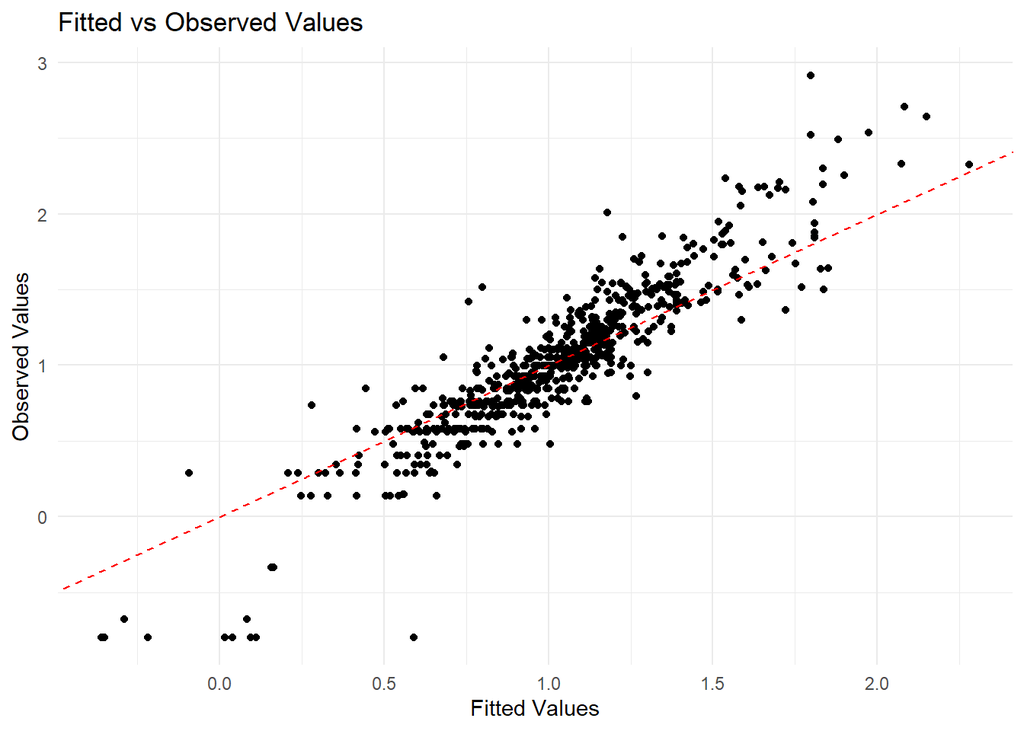

```r
# get fitted values
fitted_values<- fitted(lmefit.countercovid)

# plot observed vs fitted values
ggplot(data = countercovid_long, aes(x = fitted_values, y = conc_log10)) +
  geom_point() +
  geom_abline(slope = 1, intercept = 0, linetype = "dashed", color = "red") +  # Line of perfect fit
  labs(x = "Fitted Values", y = "Observed Values") +
  ggtitle("Fitted vs Observed Values") +
  theme_minimal()
```

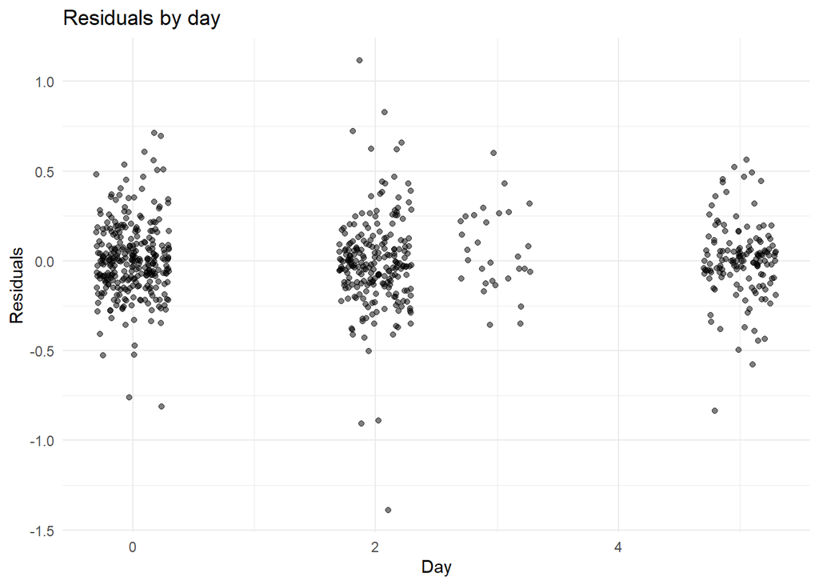

```r
# get residuals
residuals_values <- resid(lmefit.countercovid)


# plot residuals vs time
ggplot(countercovid_long, aes(x = day, y = residuals_values)) +
  geom_jitter(width = 0.3, alpha = 0.5) +
  labs(x = "Day", y = "Residuals") +
  ggtitle("Residuals by day") +
  theme_minimal()
```

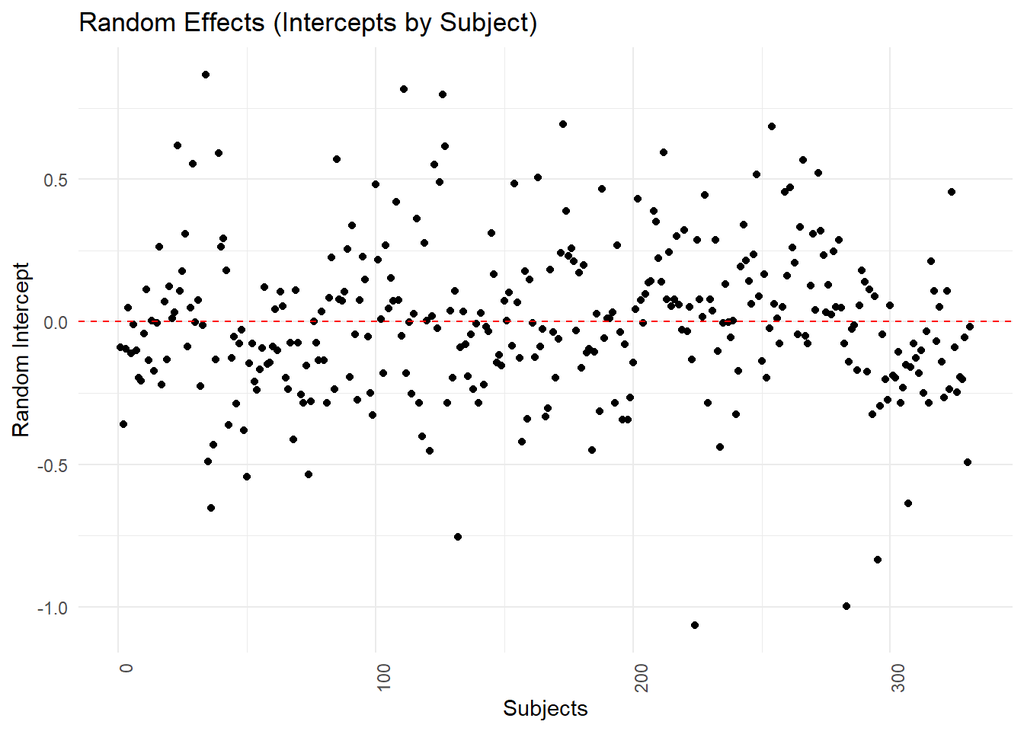

```r
# get random effects
random_effects <- ranef(lmefit.countercovid)

#plot random effects
ggplot(random_effects, aes(x = c(1:nrow(countercovid_surv)), y = `(Intercept)`)) +
  geom_point() +
  geom_hline(yintercept = 0, linetype = "dashed", color = "red") +
  labs(x = "Subjects", y = "Random Intercept") +
  ggtitle("Random Effects (Intercepts by Subject)") +
  theme_minimal() +
  theme(axis.text.x = element_text(angle = 90, hjust = 1))
```

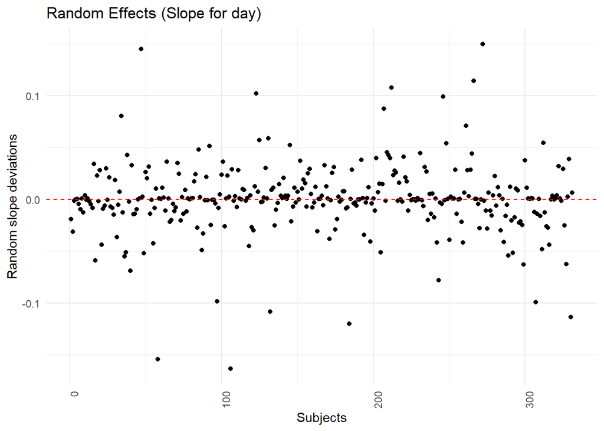

```r
#plot random effects
ggplot(random_effects, aes(x = c(1:nrow(countercovid_surv)), y = `day`)) +
  geom_point() +
  geom_hline(yintercept = 0, linetype = "dashed", color = "red") +
  labs(x = "Subjects", y = "Random slope deviations") +
  ggtitle("Random Effects (Slope for day)") +
  theme_minimal() +
  theme(axis.text.x = element_text(angle = 90, hjust = 1))
```

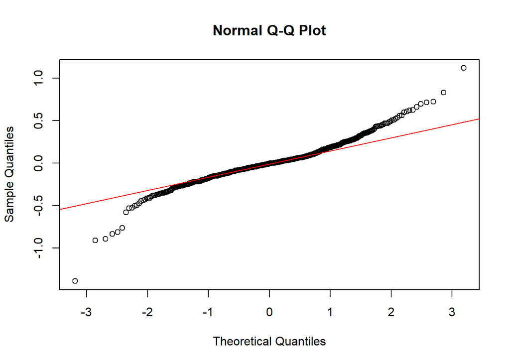

```r
# qq plot for residuals
qqnorm(resid(lmefit.countercovid))

qqline(resid(lmefit.countercovid), col = "red")
```

#### 5.2 Survival submodel

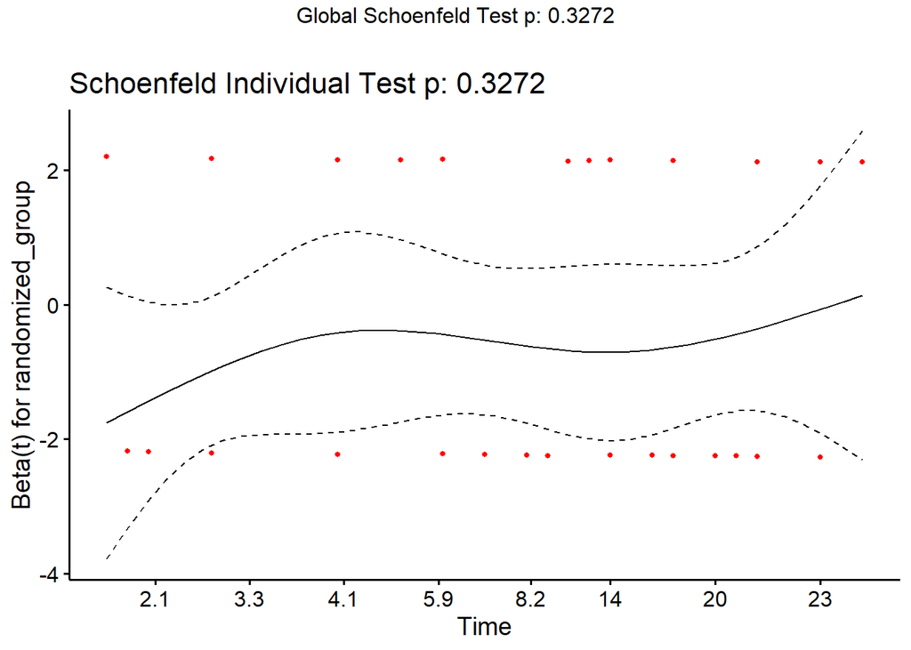

```r
test.ph <- cox.zph(coxfit.countercovid_28)
survminer::ggcoxzph(test.ph)
```

Proportional hazards assumption holds.

#### 5.3 Traceplots joint model: 28-day endpoint

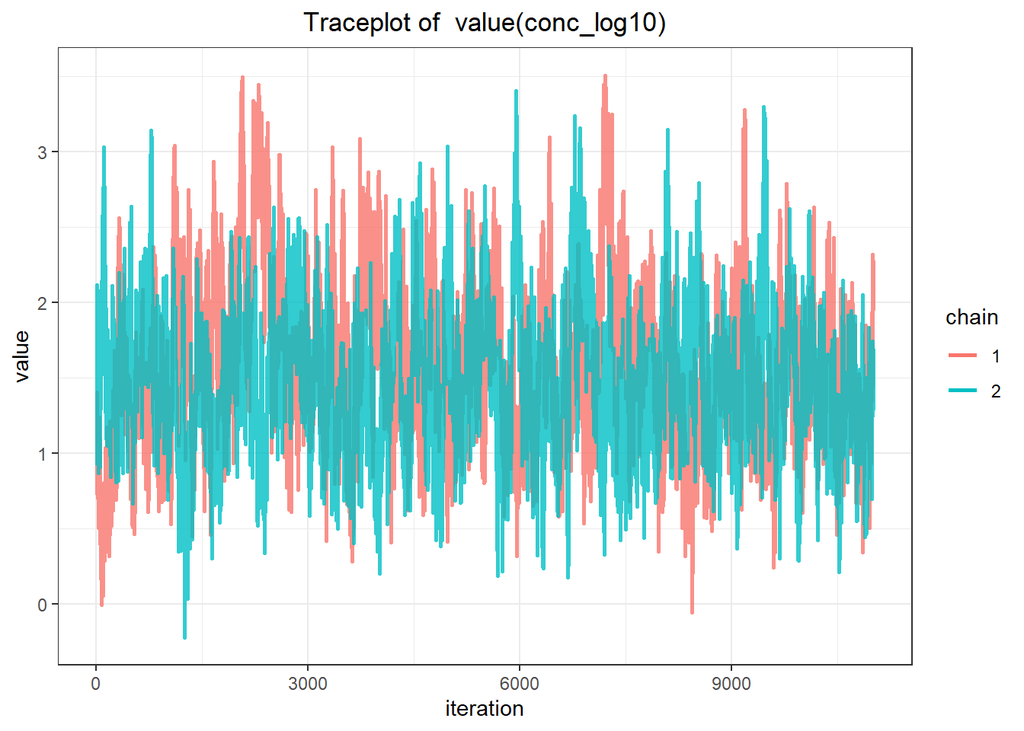

```r
ggtraceplot(jointfit.countercovid_28, "alphas")
```

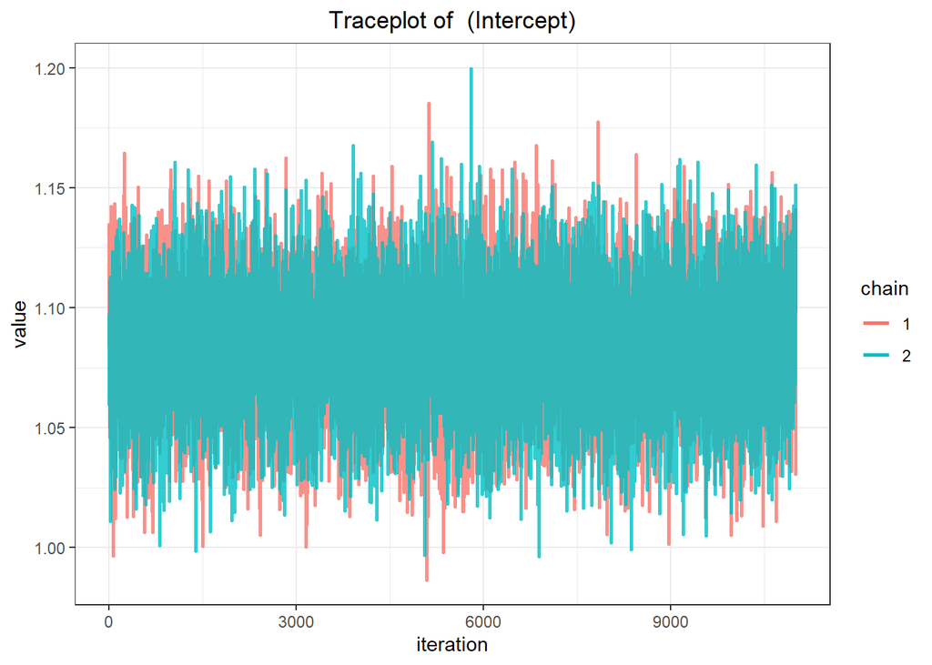

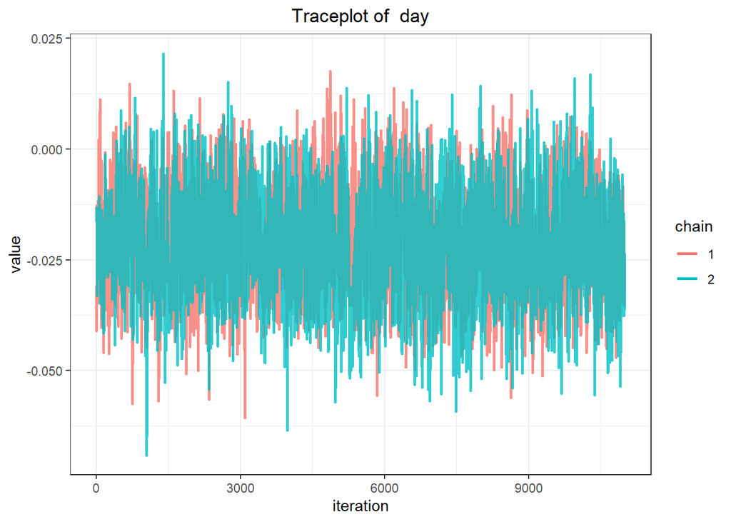

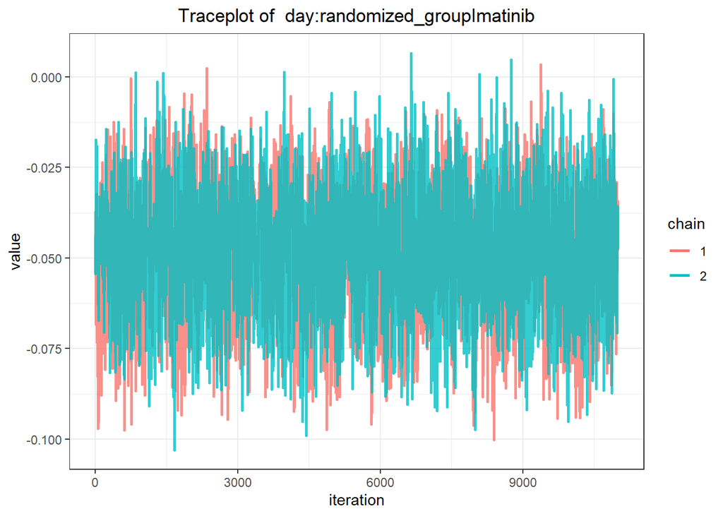

```r
ggtraceplot(jointfit.countercovid_28, "betas")
```

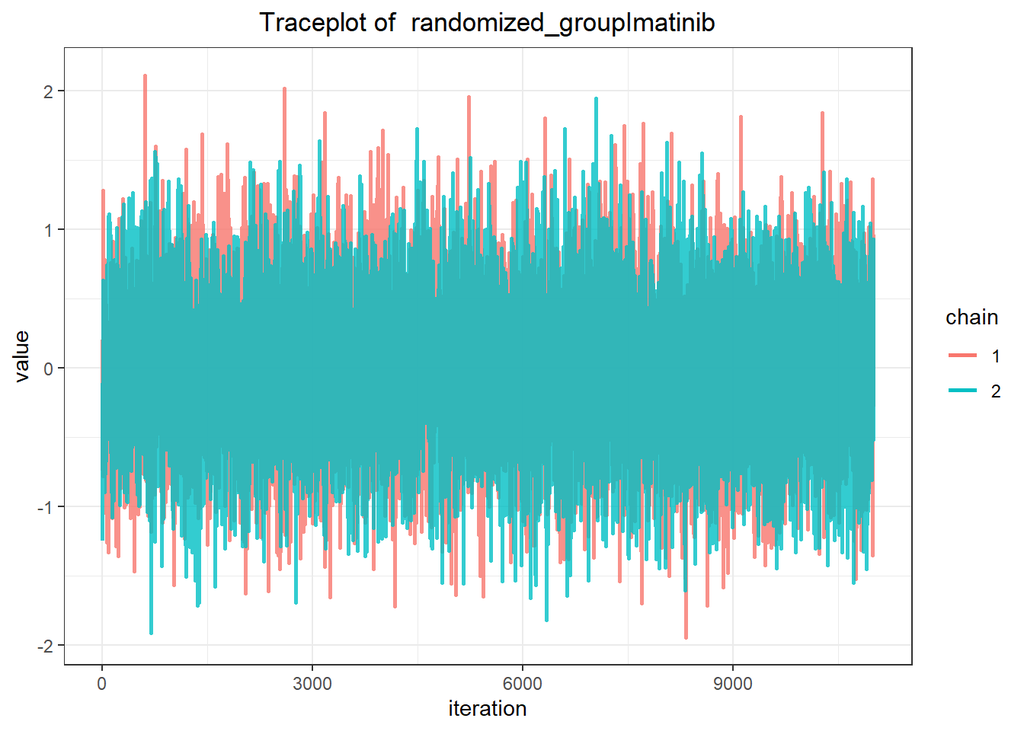

```r
ggtraceplot(jointfit.countercovid_28, "gammas")
```

#### 5.4 Traceplots joint model: 90-day endpoint

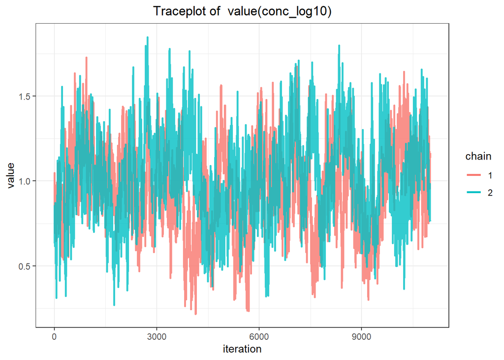

```r
ggtraceplot(jointfit.countercovid_90, "alphas")
```

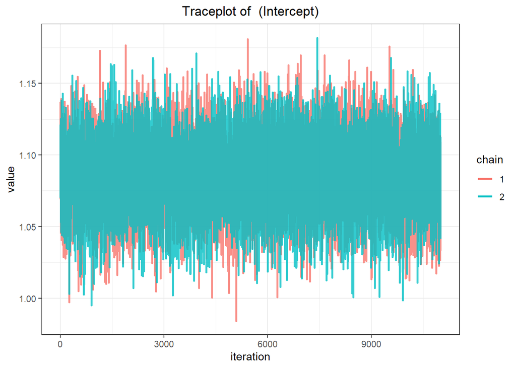

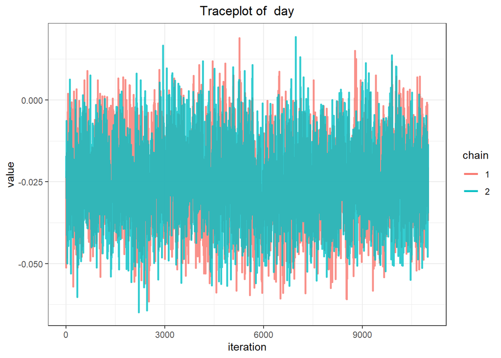

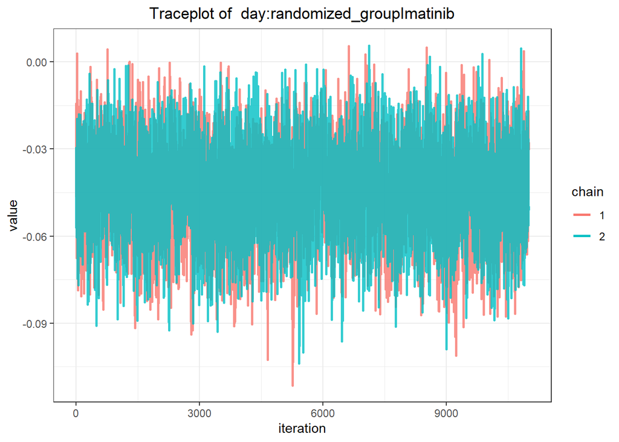

```r
ggtraceplot(jointfit.countercovid_90, "betas")
```

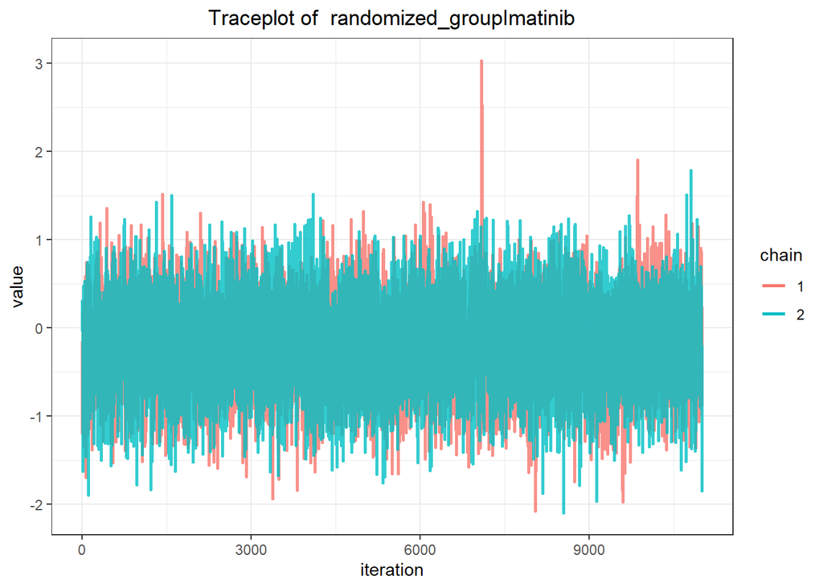

```r
ggtraceplot(jointfit.countercovid_90, "gammas")
```